# DATA 202 Homework 4

Trey Tipton

2022-10-27

## The Purpose

Our goal is to do an EDA on world populations by country.

## Loading Data

```r
codes <- read_csv("data/country-codes.csv")

pop <- read_csv("data/country-population.csv")
```

## Querying Raw Population Data

Create a table that plots country populations over time for subsets (of you choice) of the years and of the countries. Get the country names from the other table.

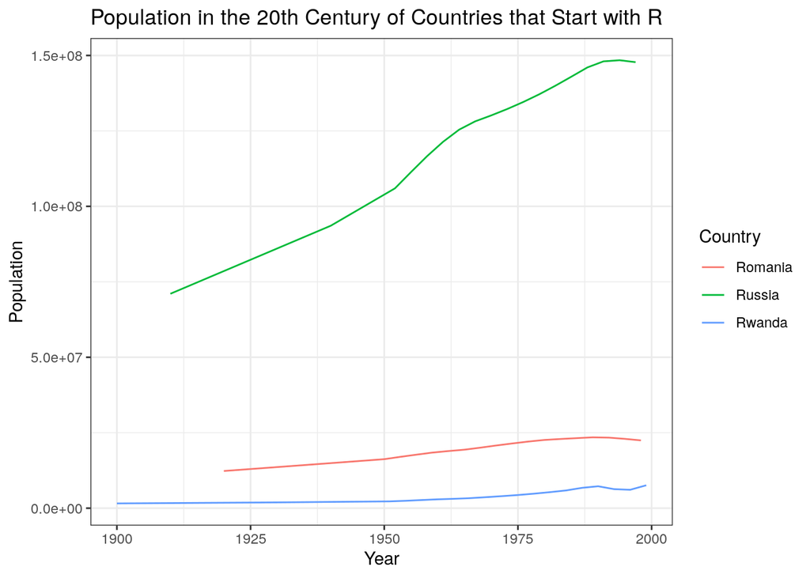

```r
pop2 <- pop %>%
  pivot_longer(-country, names_to = 'Year', values_to = 'Population') %>%
  na.omit(country)

countries <- pop2 %>%
  left_join(codes, by = c('country' = 'code')) %>%
  rename('Country' = 'country.y') %>%
  mutate(Year = as.numeric(Year))


countries %>%
  # Filter for countries that start with the letter R
  filter(country == c('rou', 'rwa', 'rus')) %>%
  # Filter for the 20th century
  filter(Year > 1899) %>%
  filter(Year < 2000) %>%
  ggplot() +
  aes(x = Year, y = Population, color = Country) +
  geom_line() +
  labs(title = 'Population in the 20th Century of Countries that Start with R', x = 'Year', y = 'Population',
       color = 'Country')
```

```r
countries %>%
  # Filter for countries that start with the letter R
  filter(country == c('rou', 'rwa', 'rus')) %>%
  pivot_wider(names_from = Year, values_from = Population) %>%
  select(Country, '1900', '1910', '1920', '1997','1998', '1999') %>%
  knitr::kable()
```

| Country | 1900 | 1910 | 1920 | 1997 | 1998 | 1999 |
| --- | --- | --- | --- | --- | --- | --- |
| Romania | NA | NA | 12320811 | NA | 22458737 | NA |
| Russia | NA | 71044207 | NA | 147772805 | NA | NA |
| Rwanda | 1576436 | NA | NA | NA | NA | 7585143 |

For the countries that start with the letter R, Russia begins with the highest population and also has the highest increase over the 20th century. Rwanda and Romania are consistently parallel, with little change over this time period; Rwanda has the lowest population of all three.